# DCN - Stage2 Analyses

October 2023

# 1 Project Description

This project is based on the Stage 1 registered report submitted at Developmental Cognitive Neuroscience (Demidenko et al [2022](https://osf.io/a6t8k)). The proposal was to use a sub-sample of the full yr 2 (follow-up to baseline) ABCD sample. This includes 1000 participants for the initial analysis and a held out 1000 participants for the follow-up LSEM/EFA model. The below is the exclusion and descriptive statistics for the samples.

# 2 ABCD Subsampling

Consistent with the registered report, we first subsample 1000 x 2 ABCD data on which QC is performed to arrived at the final sample. The complete list of ABCD NDA subjects are gathered, then for subsampling, the base R row subsetting method is used, see [subseting](https://www.statmethods.net/management/subset.html).

## 2.1 Loading data

For instance, take the dataframe `NDAyr2_dat` and use row/column subsetting the df using R’s column/row [indexing](https://sparkbyexamples.com/r-programming/select-rows-by-index-in-r/). Here, `df[df1 var %in% df2 var,]` takes all of the rows that are in the 2nd field with all of the columns. Below the same is used but `!` is used to specify for those not in the list/df, e.g. `df[!df1 var %in% df2 var,]`. When df1 variable is not in df2 var, take rows/columns

```r
# Load subjects who have yr 2 folders
ABCC_yr2_subs = read_csv("../../../Data/ABCD/ABCC_MSI/ABCC_subjectsWyr2.csv",show_col_types = F)

# Load NDA yr dat
NDA_yr2_dat = read_csv("../output/NDA_MID_QC_20230723.csv",show_col_types = F)
# create same var name
ABCC_yr2_subs$subjectkey <- str_replace(ABCC_yr2_subs$ABCC_yr2_ids, "sub-NDAR", "NDAR_")

# select subs that match between NDA and ABCC
subset_MIDdat = NDA_yr2_dat[NDA_yr2_dat$subjectkey %in% ABCC_yr2_subs$subjectkey,]
```

## 2.2 Describe NDA Yr2

As specified in the registered report, a random subsample ~1000 ABCD subjects or selected from the NDA full sampel data. Here, randomly subsample across sites to avoid variability between sites (described in the manuscript). The figure displays the distribution of the subjects across sites from the NDA data across sites. The year two sample from NDA archive is: 10414 subjects.

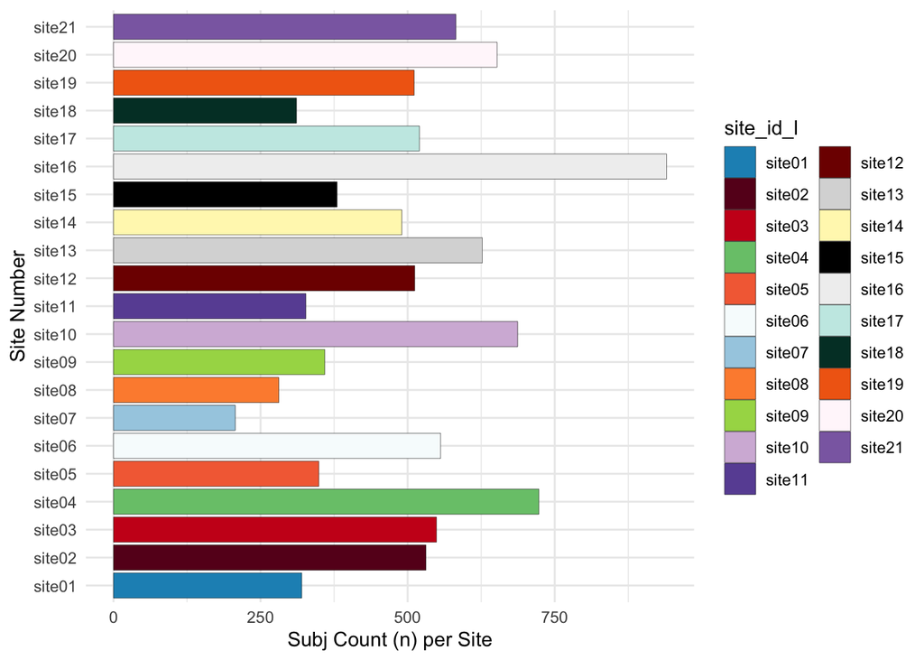

```r
NDA_yr2_dat %>%
  dplyr::group_by(site_id_l) %>%
  dplyr::summarize(Sites = n()) %>%
  ungroup() %>%
  ggplot(aes(x = site_id_l, y = Sites, fill = site_id_l)) +
  geom_bar(stat="identity", colour = "black", size = .1) +
  xlab("Site Number") +
  ylab("Subj Count (n) per Site") +
  scale_fill_manual(values = pal) +
  coord_flip() +
  theme_minimal()
```

## 2.3 Sample primary, heldout + UM

Generating first, second and Uni of Michigan only datasets.

- First_1000 : Random subsample on which CFA, ESEM and CFA model is test
- Second_1000 : Random [held out] subsample on which EFA model is evaluated using CFA and LSEM is performed.
- UM_only : participants only from the University of Michigan (UM), site = 13.

A seed is specified using [set.seed](http://rfunction.com/archives/62) so results are reproducible (random selection is baised by seed) and subjects are not misattributed to groups as a result of varying seeds. Site 22 is excluded as this site is no longer a site after baseline. The subjects are grouped by site and a random number of 48 subjects from each site are selected. N = 48 was selected as a way to achieve 1000 subjects. Note, this results in more subjects than 1000, as 48 x 21 = 1008 This is preferred to ensure equal sampling.

First, the first_1000 is generated, data.frame = `First_1000`. Then, subsample second set of 1000 subjects. So the same subjects are not in both, ensure the subjects in `First_1000` are not in the second subsamle using a [not in formula]. The same method is used to subsample `Second_1000` as described for `First_1000`.

In addition, also select the University of Michigan *only* sample by subsetting based site==13 in `site_id_l` as this is used in our site-specific sensitivity check (recall, MLS and AHRB sample were collected on GE scanners at the Unversity of Michigan MRI facilities)

```r
set.seed(1000)
First_1000 = subset_MIDdat %>% filter(site_id_l != "site22") %>% group_by(site_id_l) %>% slice_sample(n = 48)
First_1000$subsample = "First_1k"
First_1000$subject = First_1000$subjectkey %>% gsub("_","",.)

Second_1000 = subset_MIDdat[!subset_MIDdat$subjectkey %in% First_1000$subjectkey,] %>% filter(site_id_l != "site22") %>% group_by(site_id_l) %>% slice_sample(n = 48)
Second_1000$subsample = "Second_1k"
Second_1000$subject = Second_1000$subjectkey %>% gsub("_","",.)

ABCD_UMonly = subset_MIDdat %>% filter(site_id_l == "site13")
ABCD_UMonly$subsample = "UM_only"
ABCD_UMonly$subject = ABCD_UMonly$subjectkey %>% gsub("_","",.)
```

## 2.4 Describe samples

Below we ensure that the above resulted in an equal number of subjects across site.

```r
First_1000 %>%
  dplyr::group_by(site_id_l) %>%
  dplyr::summarize(n())
```

```
## # A tibble: 21 × 2
##    site_id_l `n()`
##    <chr>     <int>
##  1 site01       48
##  2 site02       48
##  3 site03       48
##  4 site04       48
##  5 site05       48
##  6 site06       48
##  7 site07       48
##  8 site08       48
##  9 site09       48
## 10 site10       48
## # … with 11 more rows
```

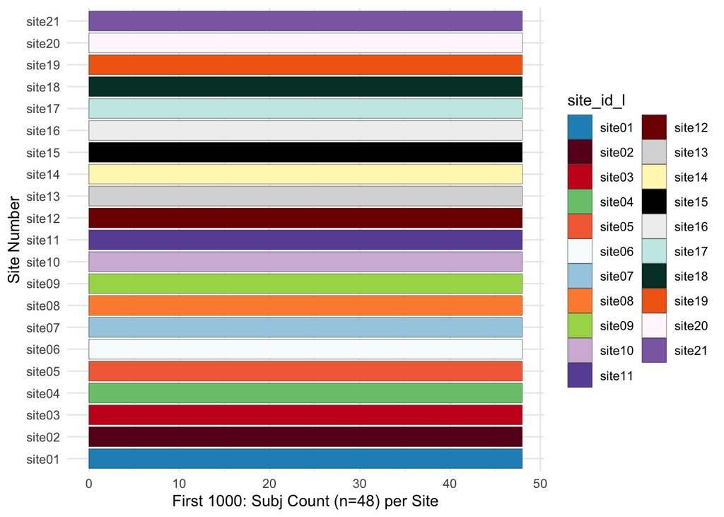

```r
First_1000 %>%
  dplyr::group_by(site_id_l) %>%
  dplyr::summarize(Sites = n()) %>%
  ungroup() %>%
  ggplot(aes(x = site_id_l, y = Sites, fill = site_id_l)) +
  geom_bar(stat="identity", colour = "black", size = .1) +
  scale_fill_manual(values = pal) +
  xlab("Site Number") +
  ylab("First 1000: Subj Count (n=48) per Site") +
  coord_flip() +
  theme_minimal()
```

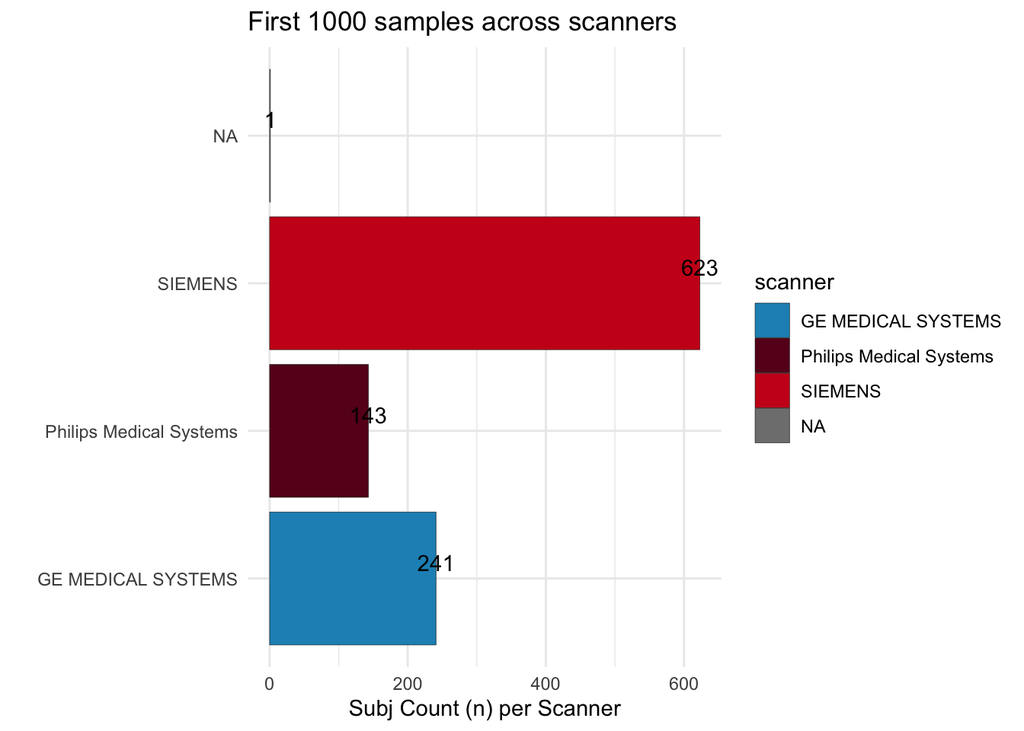

```r
First_1000 %>%
  dplyr::group_by(scanner) %>%
  dplyr::summarize(scan_n = n()) %>%
  ungroup() %>%
  ggplot(aes(x = scanner, y = scan_n, fill = scanner)) +
  geom_bar(stat="identity", colour = "black", size = .1) +
  geom_text(aes(x = scanner, y = scan_n, label = scan_n), vjust = -0.5) + # add text labels
  labs(title = "First 1000 samples across scanners") +
  xlab("") +
  ylab("Subj Count (n) per Scanner") +
  scale_fill_manual(values = pal) +
  coord_flip() +
  theme_minimal()
```

```r
Second_1000 %>%
  dplyr::group_by(site_id_l) %>%
  dplyr::summarize(n())
```

```
## # A tibble: 21 × 2
##    site_id_l `n()`
##    <chr>     <int>
##  1 site01       48
##  2 site02       48
##  3 site03       48
##  4 site04       48
##  5 site05       48
##  6 site06       48
##  7 site07       48
##  8 site08       48
##  9 site09       48
## 10 site10       48
## # … with 11 more rows
```

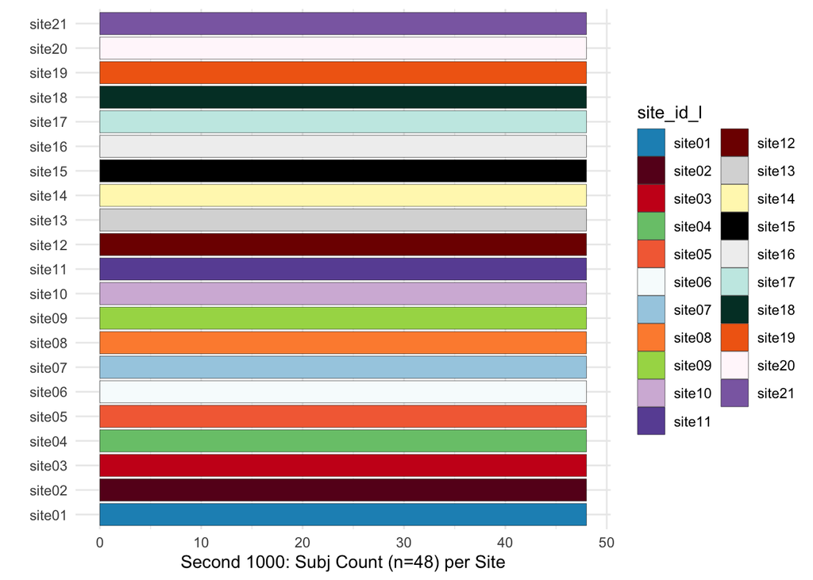

```r
Second_1000 %>%
  dplyr::group_by(site_id_l) %>%
  dplyr::summarize(Sites = n()) %>%
  ungroup() %>%
  ggplot(aes(x = site_id_l, y = Sites, fill = site_id_l)) +
  geom_bar(stat="identity", colour = "black", size = .1) +
  scale_fill_manual(values = pal) +
  xlab("") +
  ylab("Second 1000: Subj Count (n=48) per Site") +
  coord_flip() +
  theme_minimal()
```

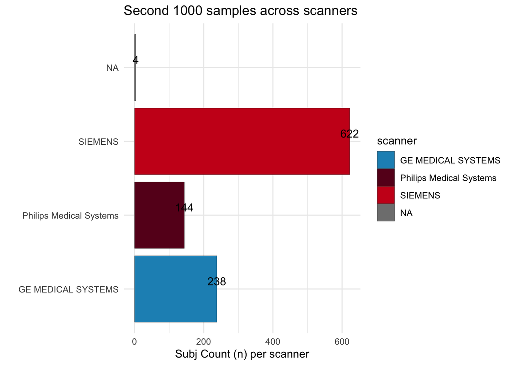

```r
Second_1000 %>%
  dplyr::group_by(scanner) %>%
  dplyr::summarize(scan_n = n()) %>%
  ungroup() %>%
  ggplot(aes(x = scanner, y = scan_n, fill = scanner)) +
  geom_bar(stat="identity", colour = "black", size = .1) +
  geom_text(aes(x = scanner, y = scan_n, label = scan_n), vjust = -0.5) + # add text labels
  labs(title = "Second 1000 samples across scanners") +
  xlab("") +
  ylab("Subj Count (n) per scanner") +
  scale_fill_manual(values = pal) +
  coord_flip() +
  theme_minimal()
```

For the fMRIprep/MRIQC steps, will need a list to find out which subjects and subjects’ runs are available in the ABCD-BIDS Community (ABCC) for the MID task and which pass preprocessing, etc. Specifically, not all IDs will have Year 2 [Follow-up] folders (anat & func & fmap). This is generated based on the data available on ABCC DCAN servers as of **January 2023 (post Stage 1 Acceptance)**.

```r
id_list = data.frame(subj_ids = c(First_1000$subjectkey %>% gsub("_","",.),
                                  Second_1000$subjectkey %>% gsub("_","",.),
                                  ABCD_UMonly$subjectkey %>% gsub("_","",.)),
                     subsample = c(First_1000$subsample,
                                   Second_1000$subsample,
                                   ABCD_UMonly$subsample)
                     )

uniq_ids = distinct(id_list, subj_ids, .keep_all = TRUE)
```

From the subsample of in `First_1000`, `Second_1000` and `ABCD_UMonly` from the Year 2 NDA list of subjects, below are the number of subjects on the ABCC that had:

1. Anatomy folder
2. fmap folder
3. MID folder

This does not exclude subjects that 1) do not have behavioral MID data, 2) performed poorly during MID task, 3) failed Preprocessing and/or 4) had high motion. These exclusions and descriptions will described further below.

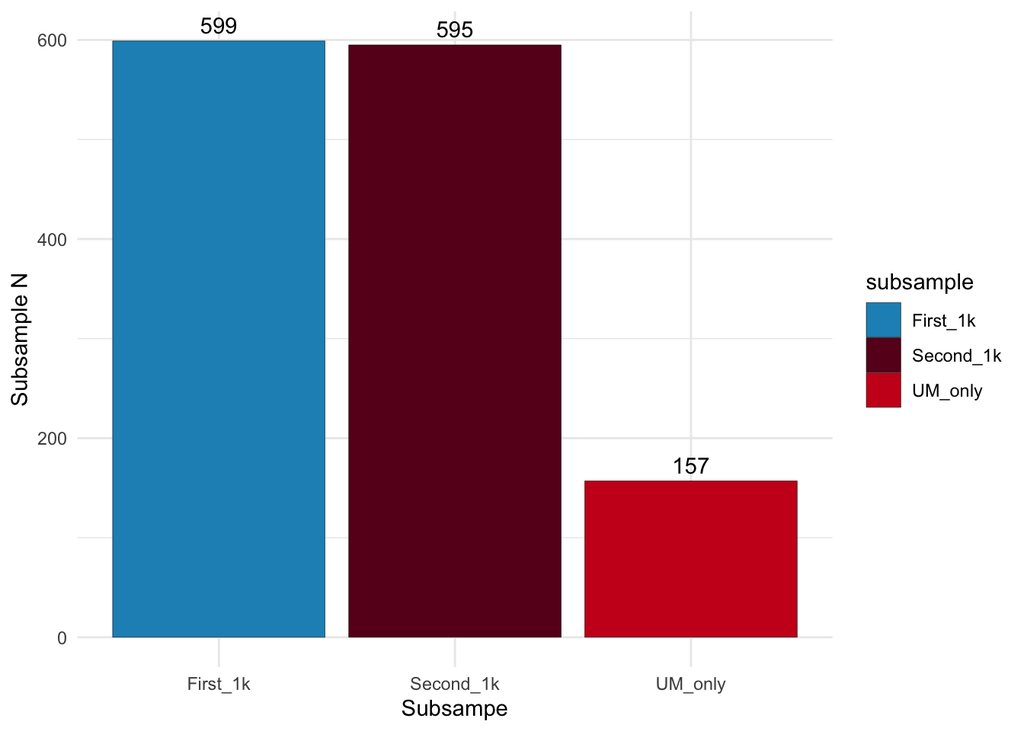

```r
scan_subj = read_csv("./subject_details/scan_ids.csv", show_col_types = FALSE)

# subjects from ID_list in scan_subj_list
available_subjects = id_list[id_list$subj_ids %in% scan_subj$scan_id,]

# count & plot
available_subjects %>%
  dplyr::group_by(subsample) %>%
  dplyr::summarize(subj_n = n()) %>%
  ungroup() %>%
  ggplot(aes(x = subj_n, y = subsample, fill = subsample)) +
  geom_bar(stat="identity", colour = "black", size = .1) +
  geom_text(aes(x = subj_n, y = subsample, label = subj_n), vjust = -0.5) + # add text labels
  scale_fill_manual(values = pal) +
  xlab("Subsample N") +
  ylab("Subsampe") +
  coord_flip() +
  theme_minimal()
```

save ut the csf of the `distinct` ids to use in the QC + GLM analyses

```r
# save out the unique values
# save .csv to iteratore over for fMRIprep related items
write_csv(distinct(available_subjects, subj_ids, .keep_all = TRUE),
          "./subject_details/distinct_subset_ids.csv")
```

# 3 QC Data

Load data files for QC. This includes data for manual QC, roi-voxel overlap, motion, accuracy and response time info

## 3.1 *ABCD*

```r
abcd_manual_qc = read.csv("../output/ABCD/qc-manual_type-task-bold.csv", sep = ",", header = TRUE)
abcd_estimate_qc = read.csv("../output/ABCD/region_overlay-roivoxels.csv", sep = ",", header = TRUE)
abcd_estimate_qc$subject = abcd_estimate_qc$subj %>% gsub("sub-","",.)
abcd_roi_qc = read.csv("../output/ABCD/task-MID_summ-mot-acc-rt.csv", sep = ",", header = TRUE)
abcd_roi_qc$subject = abcd_roi_qc$Subject %>% gsub("sub-","",.)


abcd_qc_data = left_join(x = abcd_manual_qc, y = abcd_estimate_qc, by = 'subject')
abcd_qc_data = left_join(x = abcd_qc_data, y = abcd_roi_qc, by = 'subject')
# some rows duplicated via above, removing duplicates
abcd_qc_data = abcd_qc_data[!duplicated(abcd_qc_data), ]
```

### 3.1.1 Data Qual/Avail

- Bad BOLD (1 = good, 2 = fair, 3 = bad/exclude)
- Missing BOLD Run 1 and/or Run 2
- Missing E-prime behavior

```r
abcd_qc_data %>%
  group_by(X1_good_2_fair_3_bad) %>%
  summarise(quality_bold = n()) %>%
  summarise(quality_bold, total = sum(quality_bold), percent = quality_bold/sum(quality_bold))
```

```
## # A tibble: 3 × 3
##   quality_bold total percent
##          <int> <int>   <dbl>
## 1          812  1039  0.782
## 2          160  1039  0.154
## 3           67  1039  0.0645
```

```r
abcd_qc_data %>%
  mutate(missing = if_else(miss_run1 == 1, "Missing","Available")) %>%
  group_by(missing) %>%
  summarise(missingrun1 = n()) %>%
  mutate(total = sum(missingrun1), percent = missingrun1 / sum(missingrun1))
```

```
## # A tibble: 1 × 4
##   missing   missingrun1 total percent
##   <chr>           <int> <int>   <dbl>
## 1 Available        1039  1039       1
```

```r
abcd_qc_data %>%
  mutate(missing = if_else(miss_run2 == 1, "Missing","Available")) %>%
  group_by(missing) %>%
  summarise(missingrun2 = n()) %>%
  mutate(total = sum(missingrun2), percent = missingrun2 / sum(missingrun2))
```

```
## # A tibble: 1 × 4
##   missing   missingrun2 total percent
##   <chr>           <int> <int>   <dbl>
## 1 Available        1039  1039       1
```

```r
abcd_qc_data %>%
  mutate(missing = if_else(miss_eprime == 1, "Missing","Available")) %>%
  group_by(missing) %>%
  summarise(misseprime = n()) %>%
  mutate(total = sum(misseprime), percent = misseprime / sum(misseprime))
```

```
## # A tibble: 2 × 4
##   missing   misseprime total percent
##   <chr>          <int> <int>   <dbl>
## 1 Available        817  1039   0.786
## 2 Missing          222  1039   0.214
```

```r
abcd_qc_data %>%
  filter(site=="site19") %>%
  summarise(site19 = n())
```

```
##   site19
## 1     48
```

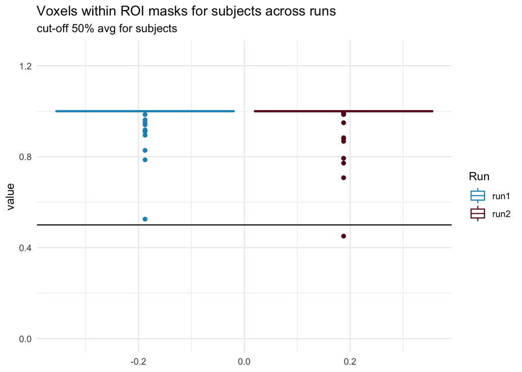

```r
abcd_qc_data$Nacc_run1 <- (abcd_qc_data$X01_L.NAcc+abcd_qc_data$X01_R.NAcc)/2
abcd_qc_data$Nacc_run2 <- (abcd_qc_data$X02_L.NAcc+abcd_qc_data$X02_R.NAcc)/2

abcd_voxel_long = abcd_qc_data %>%
  select(subject, Nacc_run1,Nacc_run2) %>%
  gather(key = "Run", value = "value", Nacc_run1:Nacc_run2)

abcd_voxel_long$Type <- str_split(abcd_voxel_long$Run, "_", simplify = TRUE)[, 1]
abcd_voxel_long$Run <- str_split(abcd_voxel_long$Run, "_", simplify = TRUE)[, 2]

abcd_voxel_long %>%
  ggplot(aes(y = value, colour = Run)) +
  geom_boxplot(na.rm = TRUE) +
  ylim(c(0,1.25))+
  scale_colour_manual(values = pal) +
  geom_hline(yintercept = .5) +
  labs(title = "Voxels within ROI masks for subjects across runs",subtitle = "cut-off 50% avg for subjects") +
  theme_minimal()
```

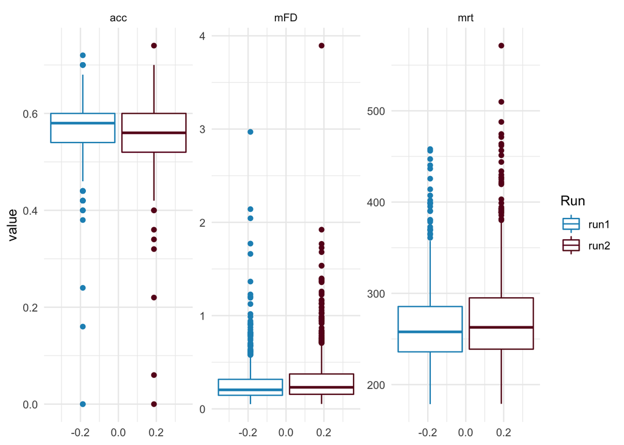

```r
abcd_bold_beh_long = abcd_qc_data %>%
  select(subject, mFD_run1:mrt_run2) %>%
  gather(key = "Run", value = "value", mFD_run1:mrt_run2)

abcd_bold_beh_long$Type <- str_split(abcd_bold_beh_long$Run, "_", simplify = TRUE)[, 1]
abcd_bold_beh_long$Run <- str_split(abcd_bold_beh_long$Run, "_", simplify = TRUE)[, 2]

abcd_bold_beh_long %>%
  ggplot(aes(y = value, colour = Run)) +
  geom_boxplot(na.rm = TRUE) +
  scale_colour_manual(values = pal) +
  facet_wrap(~Type, scales = 'free') +
  theme_minimal()
```

### 3.1.2 Exlusion

The initial N for the abcd sample was n = 1039. Subjects were excluded for the reasons described above (per the stage 1 registered report). The exclusions were in sequence:

```r
abcd_qc_data$acc_avg <- (abcd_qc_data$acc_run1+abcd_qc_data$acc_run2)/2
abcd_qc_data$mrt_avg <- (abcd_qc_data$mrt_run1+abcd_qc_data$mrt_run2)/2

abcd_qc_data %>%
  filter(X1_good_2_fair_3_bad != 3) %>%# 67 excluded
  filter(miss_run1 != 1 & miss_run2 != 1) %>% # 0 excluded
  filter(miss_eprime != 1) %>% # 197
  filter(mFD_run1 < .9 & mFD_run2 < .9) %>% # 42 excluded
  filter(Nacc_run1 > .50 & Nacc_run2 > .50) %>% # 1 excluded
#  ## behavioral exclusion, behavior described for subjects:
#  ## sub-15, below 50% avg, high reward cues as expected % near zero for $0 cues
#  ## sub-62, below 50% avg, same as 15, high reward cues at or above 60%, $ near 0%
#  ## sub-52, 40% avg, behavior dropped linearly during run 2
  filter(acc_avg > .40) %>% # excluded 4
  filter(site!="site19") %>% # 33 site19 excluded
  nrow(.)
```

```
## [1] 693
```

subset after exclusions

```r
abcd_subset = abcd_qc_data %>%
  filter(X1_good_2_fair_3_bad != 3) %>% # 64 excluded
  filter(miss_run1 != 1 & miss_run2 != 1) %>% # 0 excluded
  filter(miss_eprime != 1) %>% # 0 excluded
  filter(mFD_run1 < .9 & mFD_run2 < .9) %>% # 42 excluded
  filter(Nacc_run1 > .50 & Nacc_run2 > .50) %>% # 0 excluded
  filter(acc_avg > .40) %>% # excluded 4=
  filter(site!="site19") %>%
  select(subject, subsample, mFD_run1:mrt_run2)
```

```r
abcd_subs = abcd_subset %>%
  select(subject,subsample)

write.table(abcd_subs, "../output/ABCD/abcd_final_subjs.tsv", sep = "\t", col.names = FALSE, row.names = FALSE)
```

The final ABCD sample contains **693** subjects. These are used in the subsequent steps

## 3.2 *AHRB*

Data were QC’d for several factors and exclusion steps are based on several key items:

- availability of data &
- motion
- signal
- behavioral

### 3.2.1 Load data files for QC

```r
ahrb_manual_qc = read.csv("../output/AHRB/qc-manual_type-task-bold.csv", sep = ",", header = TRUE)
ahrb_estimate_qc = read.csv("../output/AHRB/region_overlay-roivoxels.csv", sep = ",", header = TRUE) %>%
  rename(subject = 'subj')
ahrb_roi_qc = read.csv("../output/AHRB/subs-103_task-mid_summ-mot-acc-rt.csv", sep = ",", header = TRUE) %>%
  rename(subject = 'Subject')


ahrb_qc_data = left_join(x = ahrb_manual_qc, y = ahrb_estimate_qc, by = 'subject')
ahrb_qc_data = left_join(x = ahrb_qc_data, y = ahrb_roi_qc, by = 'subject')

# relabel NA which = 0
ahrb_qc_data$miss_run1[is.na(ahrb_qc_data$miss_run1)] <- 0
ahrb_qc_data$miss_run2[is.na(ahrb_qc_data$miss_run2)] <- 0
ahrb_qc_data$miss_eprime[is.na(ahrb_qc_data$miss_eprime)] <- 0
```

### 3.2.2 Data Qual/Avail

- Bad BOLD (1 = good, 2 = fair, 3 = bad/exclude)
- Missing BOLD Run 1 and/or Run 2
- Missing E-prime behavior

```r
ahrb_qc_data %>%
  group_by(X1_good_2_fair_3_bad) %>%
  summarise(quality_bold = n()) %>%
  summarise(quality_bold, total = sum(quality_bold), percent = quality_bold/sum(quality_bold))
```

```
## # A tibble: 3 × 3
##   quality_bold total percent
##          <int> <int>   <dbl>
## 1           73   108  0.676
## 2           32   108  0.296
## 3            3   108  0.0278
```

```r
ahrb_qc_data %>%
  mutate(missing = if_else(miss_run1 == 1, "Missing","Available")) %>%
  group_by(missing) %>%
  summarise(missingrun1 = n()) %>%
  mutate(total_run1 = sum(missingrun1), percent = missingrun1 / sum(missingrun1))
```

```
## # A tibble: 1 × 4
##   missing   missingrun1 total_run1 percent
##   <chr>           <int>      <int>   <dbl>
## 1 Available         108        108       1
```

```r
ahrb_qc_data %>%
  mutate(missing = if_else(miss_run2 == 1, "Missing","Available")) %>%
  group_by(missing) %>%
  summarise(missingrun2 = n()) %>%
  mutate(total_run2 = sum(missingrun2), percent = missingrun2 / sum(missingrun2))
```

```
## # A tibble: 2 × 4
##   missing   missingrun2 total_run2 percent
##   <chr>           <int>      <int>   <dbl>
## 1 Available         107        108 0.991
## 2 Missing             1        108 0.00926
```

```r
ahrb_qc_data %>%
  mutate(missing = if_else(miss_eprime == 1, "Missing","Available")) %>%
  group_by(missing) %>%
  summarise(misseprime = n()) %>%
  mutate(total_eprime = sum(misseprime), percent = misseprime / sum(misseprime))
```

```
## # A tibble: 2 × 4
##   missing   misseprime total_eprime percent
##   <chr>          <int>        <int>   <dbl>
## 1 Available        107          108 0.991
## 2 Missing            1          108 0.00926
```

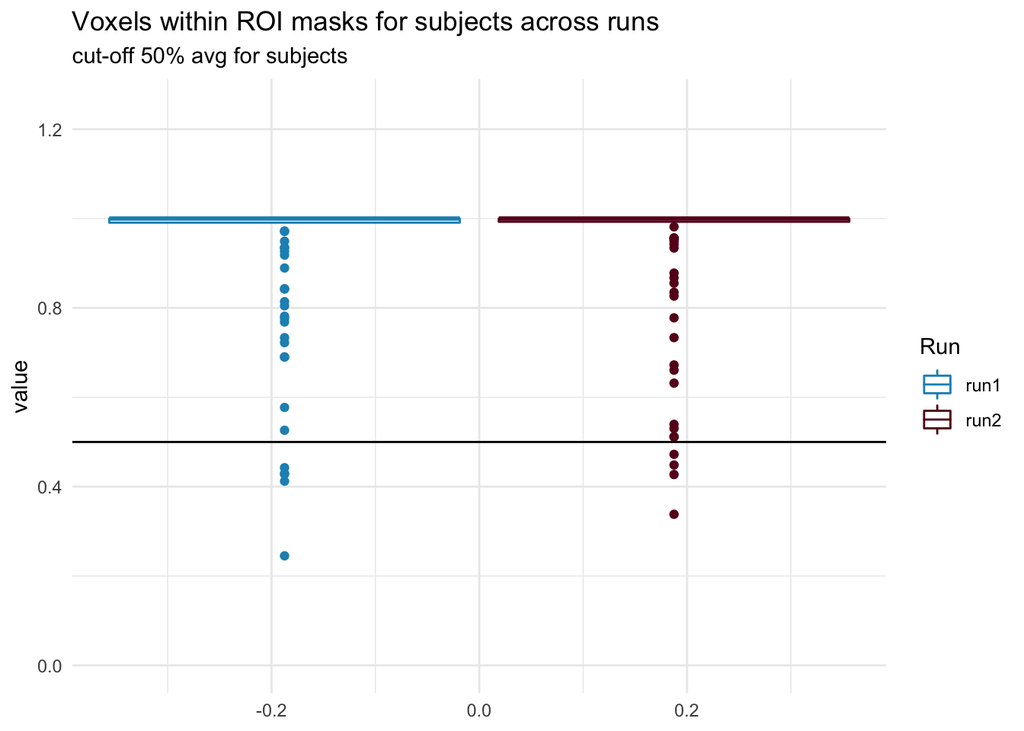

```r
ahrb_qc_data$Nacc_run1 <- (ahrb_qc_data$X01_L.NAcc+ahrb_qc_data$X01_R.NAcc)/2
ahrb_qc_data$Nacc_run2 <- (ahrb_qc_data$X02_L.NAcc+ahrb_qc_data$X02_R.NAcc)/2

ahrb_voxel_long = ahrb_qc_data %>%
  select(subject, Nacc_run1,Nacc_run2) %>%
  gather(key = "Run", value = "value", Nacc_run1:Nacc_run2)

ahrb_voxel_long$Type <- str_split(ahrb_voxel_long$Run, "_", simplify = TRUE)[, 1]
ahrb_voxel_long$Run <- str_split(ahrb_voxel_long$Run, "_", simplify = TRUE)[, 2]

ahrb_voxel_long %>%
  ggplot(aes(y = value, colour = Run)) +
  geom_boxplot(na.rm = TRUE) +
  ylim(c(0,1.25))+
  scale_colour_manual(values = pal) +
  geom_hline(yintercept = .5) +
  labs(title = "Voxels within ROI masks for subjects across runs",subtitle = "cut-off 50% avg for subjects") +
  theme_minimal()
```

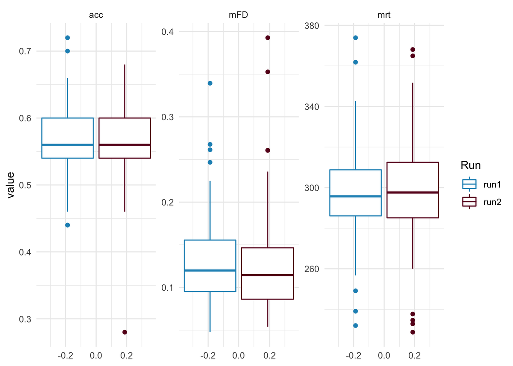

```r
ahrb_bold_beh_long = ahrb_qc_data %>%
  select(subject, mFD_run1:mrt_run2) %>%
  gather(key = "Run", value = "value", mFD_run1:mrt_run2)

ahrb_bold_beh_long$Type <- str_split(ahrb_bold_beh_long$Run, "_", simplify = TRUE)[, 1]
ahrb_bold_beh_long$Run <- str_split(ahrb_bold_beh_long$Run, "_", simplify = TRUE)[, 2]

ahrb_bold_beh_long %>%
  ggplot(aes(y = value, colour = Run)) +
  geom_boxplot(na.rm = TRUE) +
  scale_colour_manual(values = pal) +
  facet_wrap(~Type, scales = 'free') +
  theme_minimal()
```

### 3.2.3 Exlusion

The initial N for the ahrb sample was n = 108. Subjects were excluded for the reasons described above (per the stage 1 registered report). The exclusions were in sequence:

- [3] excluded that had bad or non-existent MID BOLD data
- [2] excluded that were missing e-prime data for run 01 or run 02
- [0] excluded for mFD > .90
- [5] excluded for having ROI coverage of < 50% for the NAcc across run01 and run02
- [1] excluded for poor performance displayed and notes

```r
ahrb_qc_data$acc_avg <- (ahrb_qc_data$acc_run1+ahrb_qc_data$acc_run2)/2
ahrb_qc_data$mrt_avg <- (ahrb_qc_data$mrt_run1+ahrb_qc_data$mrt_run2)/2

ahrb_qc_data %>%
  filter(X1_good_2_fair_3_bad != 3) %>% # 3 excluded
  filter(miss_run1 != 1 & miss_run2 != 1 & miss_eprime != 1) %>% # 2 excluded
  filter(mFD_run1 < .9 & mFD_run2 < .9) %>% # 0 excluded
  filter(Nacc_run1 > .50 & Nacc_run2 > .50) %>% # 5 excluded

  # behavioral exclusion, behavior described for subjects:
  # sub-15, below 50% avg, high reward cues as expected % near zero for $0 cues
  # sub-62, below 50% avg, same as 15, high reward cues at or above 60%, $ near 0%
  # sub-52, 40% avg, behavior dropped linearly during run 2
  filter(acc_avg > .40) %>% # excluded 1, sub-52
  nrow(.)
```

```
## [1] 97
```

subset data after exclusions

```r
ahrb_subset = ahrb_qc_data %>%
  filter(X1_good_2_fair_3_bad != 3) %>% # 3 excluded
  filter(miss_run1 != 1 & miss_run2 != 1 & miss_eprime != 1) %>% # 2 excluded
  filter(mFD_run1 < .9 & mFD_run2 < .9) %>% # 0 excluded
  filter(Nacc_run1 > .50 & Nacc_run2 > .50) %>% # 5 excluded
  filter(acc_avg > .40) %>%
  select(subject, mFD_run1:mrt_run2)
```

```r
ahrb_subs = ahrb_subset %>%
  select(subject)

write.table(ahrb_subs, "../output/AHRB/ahrb_final_subjs.tsv", sep = "\t", col.names = FALSE, row.names = FALSE)
```

The final AHRB sample contains **97** subjects. These are used in the subsequent steps

## 3.3 *MLS*

QC data to provide exclusion details based on steps relating to:

- quality of bold and availability of data
- motion
- signal
- behavioral

### 3.3.1 Load data files for QC

```r
mls_manual_qc = read.csv("../output/MLS/qc-manual_type-task-bold.csv", sep = ",", header = TRUE)
mls_estimate_qc = read.csv("../output/MLS/region_overlay-roivoxels.csv", sep = ",", header = TRUE) %>%
  rename(subject = 'subj')
mls_roi_qc = read.csv("../output/MLS/subs-119_task-reward_summ-mot-acc-rt.csv", sep = ",", header = TRUE) %>%
  rename(subject = 'Subject')

mls_qc_data = left_join(x = mls_manual_qc, y = mls_estimate_qc, by = 'subject')
mls_qc_data = left_join(x = mls_qc_data, y = mls_roi_qc, by = 'subject')

# relabel NA which = 0
mls_qc_data$miss_run1[is.na(mls_qc_data$miss_run1)] <- 0
mls_qc_data$miss_run2[is.na(mls_qc_data$miss_run2)] <- 0
mls_qc_data$miss_eprime[is.na(mls_qc_data$miss_eprime)] <- 0
```

### 3.3.2 Data Qual/Avail

- Bad BOLD (1 = good, 2 = fair, 3 = bad/exclude)
- Missing BOLD Run 1 and/or Run 2
- Missing E-prime behavior

```r
mls_qc_data %>%
  group_by(X1_good_2_fair_3_bad) %>%
  summarise(quality_bold = n()) %>%
  mutate(total = sum(quality_bold), percent = quality_bold / sum(quality_bold))
```

```
## # A tibble: 3 × 4
##   X1_good_2_fair_3_bad quality_bold total percent
##                  <int>        <int> <int>   <dbl>
## 1                    1          142   177  0.802
## 2                    2           16   177  0.0904
## 3                   NA           19   177  0.107
```

```r
mls_qc_data %>%
  mutate(missing = if_else(miss_run1 == 1, "Missing","Available")) %>%
  group_by(missing) %>%
  summarise(missingrun1 = n()) %>%
  mutate(total = sum(missingrun1), percent = missingrun1 / sum(missingrun1))
```

```
## # A tibble: 2 × 4
##   missing   missingrun1 total percent
##   <chr>           <int> <int>   <dbl>
## 1 Available         172   177  0.972
## 2 Missing             5   177  0.0282
```

```r
mls_qc_data %>%
  mutate(missing = if_else(miss_run2 == 1, "Missing","Available")) %>%
  group_by(missing) %>%
  summarise(missingrun2 = n()) %>%
  mutate(total = sum(missingrun2), percent = missingrun2 / sum(missingrun2))
```

```
## # A tibble: 2 × 4
##   missing   missingrun2 total percent
##   <chr>           <int> <int>   <dbl>
## 1 Available         161   177  0.910
## 2 Missing            16   177  0.0904
```

```r
mls_qc_data %>%
  mutate(missing = if_else(miss_eprime == 1, "Missing","Available")) %>%
  group_by(missing) %>%
  summarise(misseprime = n()) %>%
  mutate(total = sum(misseprime), percent = misseprime / sum(misseprime))
```

```
## # A tibble: 2 × 4
##   missing   misseprime total percent
##   <chr>          <int> <int>   <dbl>
## 1 Available        153   177   0.864
## 2 Missing           24   177   0.136
```

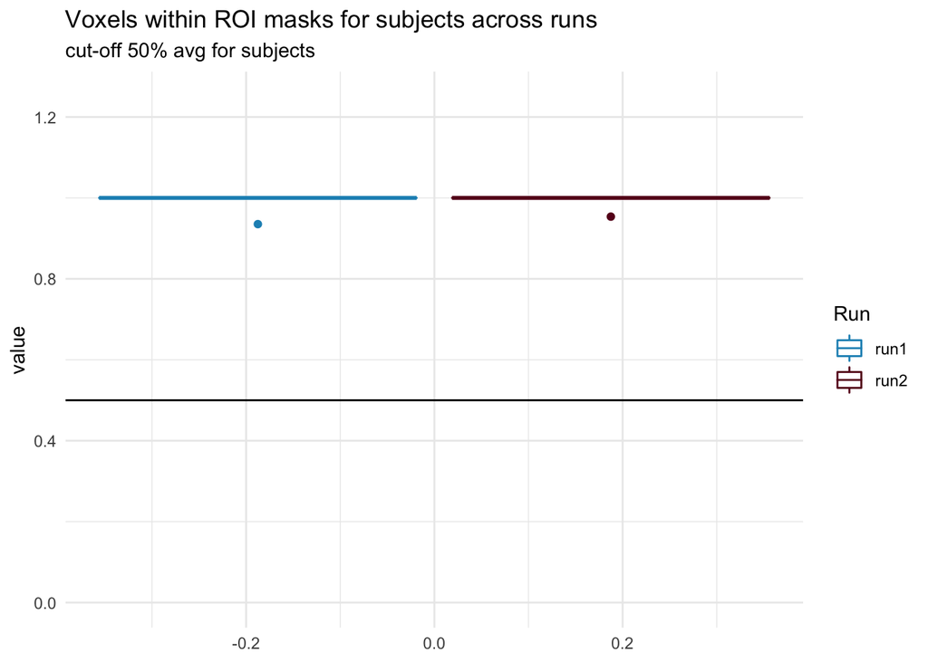

```r
mls_qc_data$Nacc_run1 <- (mls_qc_data$X01_L.NAcc+mls_qc_data$X01_R.NAcc)/2
mls_qc_data$Nacc_run2 <- (mls_qc_data$X02_L.NAcc+mls_qc_data$X02_R.NAcc)/2

mls_voxel_long = mls_qc_data %>%
  select(subject, Nacc_run1,Nacc_run2) %>%
  gather(key = "Run", value = "value", Nacc_run1:Nacc_run2)

mls_voxel_long$Type <- str_split(mls_voxel_long$Run, "_", simplify = TRUE)[, 1]
mls_voxel_long$Run <- str_split(mls_voxel_long$Run, "_", simplify = TRUE)[, 2]

mls_voxel_long %>%
  ggplot(aes(y = value, colour = Run)) +
  geom_boxplot(na.rm = TRUE) +
  ylim(c(0,1.25))+
  scale_colour_manual(values = pal) +
  geom_hline(yintercept = .5) +
  labs(title = "Voxels within ROI masks for subjects across runs", subtitle = "cut-off 50% avg for subjects") +
  theme_minimal()
```

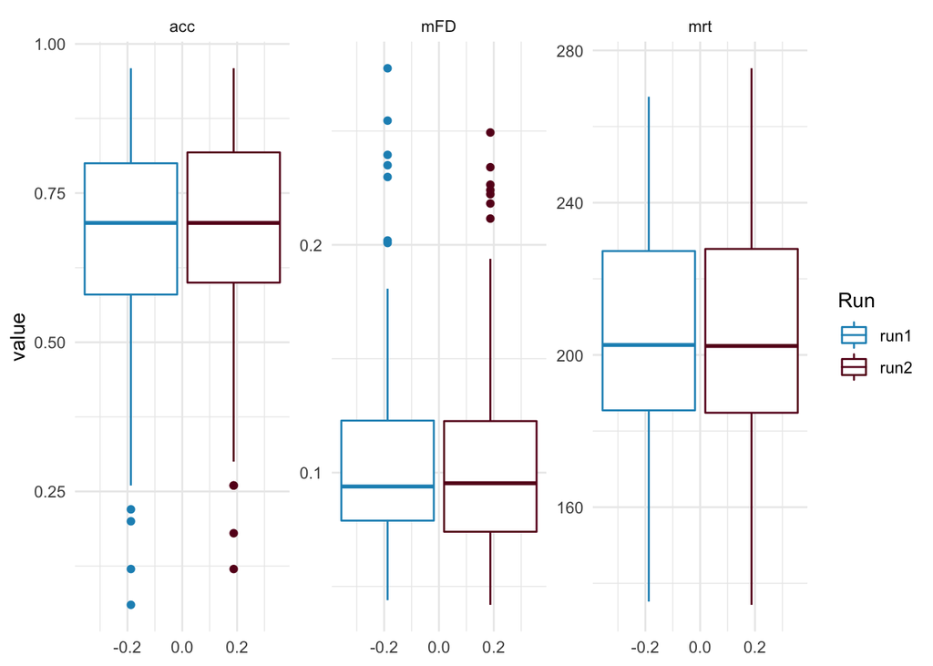

```r
mls_bold_beh_long = mls_qc_data %>%
  select(subject, mFD_run1:mrt_run2) %>%
  gather(key = "Run", value = "value", mFD_run1:mrt_run2)

mls_bold_beh_long$Type <- str_split(mls_bold_beh_long$Run, "_", simplify = TRUE)[, 1]
mls_bold_beh_long$Run <- str_split(mls_bold_beh_long$Run, "_", simplify = TRUE)[, 2]

mls_bold_beh_long %>%
  ggplot(aes(y = value, colour = Run)) +
  geom_boxplot(na.rm = TRUE) +
  scale_colour_manual(values = pal) +
  facet_wrap(~Type, scales = 'free') +
  theme_minimal()
```

### 3.3.3 Exlusion

- [19] excluded that had bad or non-existent MID BOLD data
- [39] excluded that were missing e-prime data for run 01 or run 02
- [0] excluded for mFD > .90
- [0] excluded for having ROI coverage of < 50% for the NAcc across run01 and run02
- [7] excluded for poor performance displayed in reports

```r
mls_qc_data$acc_avg <- (mls_qc_data$acc_run1+mls_qc_data$acc_run2)/2
mls_qc_data$mrt_avg <- (mls_qc_data$mrt_run1+mls_qc_data$mrt_run2)/2


mls_qc_data %>%
  filter(X1_good_2_fair_3_bad != 3) %>% # exclude 19
  filter(miss_run1 != 1 & miss_run2 != 1 & miss_eprime != 1) %>% # 39 excluded
  filter(mFD_run1 < .9 | mFD_run2 < .9) %>% # 0 excluded
  filter(Nacc_run1 > .50 & Nacc_run2 > .50) %>% # 0 excluded
  ## behavioral exclusion, behavior described for subjects:
  ## sub-155 = 16%: participant failing to respond, exclude
  ## sub-28 = 21%, barely trying run 1, run 2 gradually declining hit, exclude
  ## sub-31 = 22%, both runs generally declining performance, exclude
  ## sub-132 = 24%: second run participant failing to response, exclude
  ## sub-139 = 29%: did better 2nd run, but run 1 seemed to not hit targets, exclude
  ## sub-129 = 30%: run 1 behavior somewhat flat, but run 2 target high and stopped hitting, exclude
  ## sub-183 = 37%, started run 1 poorly, better run two but insufficient combined, exclude
  ## sub-62 = 38%, performance relatively stable, mainly trying on large rewards, and 2nd most on lg pun, include
  ## sub-102 = 40%: participant engaged no odd declines/inclines, potentially hard calibration, include
  ## sub-98 = 40%: relatively stable run 1, started slow, but high engagement run 2 better 80+% on lgreward, include
  filter(acc_avg >= .38) %>% # excluded 7, sub-52
  nrow(.)
```

```
## [1] 112
```

subset subjects data after exclusions

```r
mls_subset = mls_qc_data %>%
  filter(X1_good_2_fair_3_bad != 3) %>% # 0 excluded
  filter(miss_run1 != 1 & miss_run2 != 1 & miss_eprime != 1) %>% # 39 excluded
  filter(mFD_run1 < .9 & mFD_run2 < .9) %>% # 0 excluded
  filter(Nacc_run1 > .50 & Nacc_run2 > .50) %>% # 0 excluded
  filter(acc_avg >=.38) %>%
  select(subject, mFD_run1:mrt_run2)
```

```r
mls_subs = mls_subset %>%
  select(subject)

write.table(mls_subs, "../output/MLS/mls_final_subjs.tsv", sep = "\t", col.names = FALSE, row.names = FALSE)
```

The final MLS sample contains **112** subjects. These data are used in the subsequent steps in the analyses

# 4 Aggregate Group Performance

```r
abcd_subset$sample <- "abcd"
ahrb_subset$sample <- "ahrb"
mls_subset$sample <- "mls"

beh_comb <- rbind(abcd_subset[,-2],ahrb_subset,mls_subset)
beh_comb$acc <- (beh_comb$acc_run1+beh_comb$acc_run2) / 2
beh_comb$mrt <- (beh_comb$mrt_run1+beh_comb$mrt_run2) / 2

beh_comb_long = beh_comb %>%
  select(subject, acc, mrt, sample) %>%
  gather(key = "type", value = "value", acc:mrt)
```

report differences and test via AOV

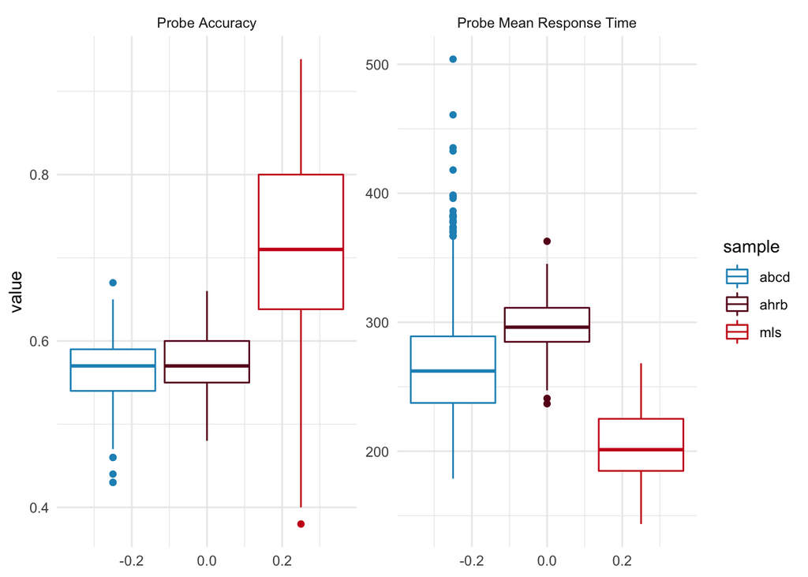

```r
beh_comb_long %>%
  mutate(type = case_when(
    type == "acc" ~ "Probe Accuracy",
    type == "mrt" ~ "Probe Mean Response Time",
    TRUE ~ type)) %>%
  ggplot(aes(y = value, colour = sample)) +
  geom_boxplot(na.rm = TRUE) +
  scale_colour_manual(values = pal) +
  facet_wrap(~type, scales = 'free') +
  theme_minimal()
```

```r
cat("Means and SD for the mean response times and probe accuracy for each of the three samples")
```

```
## Means and SD for the mean response times and probe accuracy for each of the three samples
```

```r
beh_comb_long %>%
  group_by(sample, type) %>%
  summarise(mean_value = mean(value), sd_value = sd(value))
```

```
## # A tibble: 6 × 4
## # Groups:   sample [3]
##   sample type  mean_value sd_value
##   <chr>  <chr>      <dbl>    <dbl>
## 1 abcd   acc        0.567   0.0375
## 2 abcd   mrt      269.     44.1
## 3 ahrb   acc        0.570   0.0359
## 4 ahrb   mrt      298.     20.9
## 5 mls    acc        0.705   0.133
## 6 mls    mrt      205.     27.9
```

```r
cat("ANOVA and Tukey's HSD pairwise test for sample differences in accuracy")
```

```
## ANOVA and Tukey's HSD pairwise test for sample differences in accuracy
```

```r
summary(aov(beh_comb_long$value[beh_comb_long$type=="acc"]~
              beh_comb_long$sample[beh_comb_long$type=="acc"]))
```

```
##                                                    Df Sum Sq Mean Sq F value
## beh_comb_long$sample[beh_comb_long$type == "acc"]   2  1.860  0.9299   273.7
## Residuals                                         899  3.054  0.0034
##                                                   Pr(>F)
## beh_comb_long$sample[beh_comb_long$type == "acc"] <2e-16 ***
## Residuals
## ---
## Signif. codes:  0 '***' 0.001 '**' 0.01 '*' 0.05 '.' 0.1 ' ' 1
```

```r
TukeyHSD(aov(beh_comb_long$value[beh_comb_long$type=="acc"]~
              beh_comb_long$sample[beh_comb_long$type=="acc"])
)
```

```
##   Tukey multiple comparisons of means
##     95% family-wise confidence level
##
## Fit: aov(formula = beh_comb_long$value[beh_comb_long$type == "acc"] ~ beh_comb_long$sample[beh_comb_long$type == "acc"])
##
## $`beh_comb_long$sample[beh_comb_long$type == "acc"]`
##                  diff         lwr       upr     p adj
## ahrb-abcd 0.003393136 -0.01144002 0.0182263 0.8531042
## mls-abcd  0.138075029  0.12414042 0.1520096 0.0000000
## mls-ahrb  0.134681893  0.11570387 0.1536599 0.0000000
```

```r
cat("ANOVA and Tukey's HSD pairwise test for sample differences in mean response times")
```

```
## ANOVA and Tukey's HSD pairwise test for sample differences in mean response times
```

```r
summary(aov(beh_comb_long$value[beh_comb_long$type=="mrt"]~
              beh_comb_long$sample[beh_comb_long$type=="mrt"]))
```

```
##                                                    Df  Sum Sq Mean Sq F value
## beh_comb_long$sample[beh_comb_long$type == "mrt"]   2  521352  260676   158.9
## Residuals                                         899 1474410    1640
##                                                   Pr(>F)
## beh_comb_long$sample[beh_comb_long$type == "mrt"] <2e-16 ***
## Residuals
## ---
## Signif. codes:  0 '***' 0.001 '**' 0.01 '*' 0.05 '.' 0.1 ' ' 1
```

```r
TukeyHSD(aov(beh_comb_long$value[beh_comb_long$type=="mrt"]~
              beh_comb_long$sample[beh_comb_long$type=="mrt"])
)
```

```
##   Tukey multiple comparisons of means
##     95% family-wise confidence level
##
## Fit: aov(formula = beh_comb_long$value[beh_comb_long$type == "mrt"] ~ beh_comb_long$sample[beh_comb_long$type == "mrt"])
##
## $`beh_comb_long$sample[beh_comb_long$type == "mrt"]`
##                diff        lwr       upr p adj
## ahrb-abcd  28.74886   18.44230  39.05542     0
## mls-abcd  -64.27812  -73.96034 -54.59590     0
## mls-ahrb  -93.02697 -106.21351 -79.84043     0
```